# Google Data Analytics Capstone Project : Cyclistic bike-share analysis

Inioluwa Adeyemi

2022-06-14

## BACKGROUND

Cyclistic launched a successful bike-share offering in 2016. Since then, the program has grown to a fleet of 5,824 bicycles that are geotracked and locked into a network of 692 stations across Chicago. The bikes can be unlocked from one station and returned to any other station in the system anytime. Until now, Cyclistic’s marketing strategy relied on building general awareness and appealing to broad consumer segments. One approach that helped make these things possible was the flexibility of its pricing plans: single-ride passes, full-day passes,and annual memberships. Customers who purchase single-ride or full-day passes are referred to as casual riders. Customerswho purchase annual memberships are Cyclistic members.

Cyclistic’s finance analysts have concluded that annual members are much more profitable than casual riders.

### My Role

In this scenario I am a junior data analyst at Cyclistic and my team has been tasked with the overall goal of designing marketing strategies

### Overall Goal

Design marketing strategies aimed at converting casual riders into annual members.

### Business Question

“How do annual members and casual riders use Cyclistic bikes differently?”

#PROCESS#

I used R to analyze the data because it could handle all of the data faster than Excel, and I wanted to improve on my R skills

```r
library(tidyverse) #calculations
library(lubridate) #dates
library(hms)#time
library(data.table) #exporting data frame
```

I uploaded the data of the previous 12 months (June 2021 - May 2022)from the data source divytrip into R using read_csv function to upload all individual csv files and save them in separate data frames.

```r
#to set my working directory to call my data
setwd("~/Divvy_trips2")

#load original .csv files, a years worth of data from June 2021 to May 2022
aug08_df <- read_csv("202108-divvy-tripdata.csv")
sep09_df <- read_csv("202109-divvy-tripdata.csv")
oct10_df <- read_csv("202110-divvy-tripdata.csv")
nov11_df <- read_csv("202111-divvy-tripdata.csv")
dec12_df <- read_csv("202112-divvy-tripdata.csv")
jan01_df <- read_csv("202201-divvy-tripdata.csv")
feb02_df <- read_csv("202202-divvy-tripdata.csv")
mar03_df <- read_csv("202203-divvy-tripdata.csv")
apr04_df <- read_csv("202204-divvy-tripdata.csv")
may05_df <- read_csv("202205-divvy-tripdata.csv")
jun06_df <- read_csv("202106-divvy-tripdata.csv")
jul07_df <- read_csv("202107-divvy-tripdata.csv")
```

Then I merged the 12 months into a data frame using rbind, to create a year view

```r
#merge all of the data frames into one year view
cyclistic_df <- rbind (aug08_df, sep09_df, oct10_df, nov11_df, dec12_df,
                       jan01_df, feb02_df, mar03_df, apr04_df, may05_df,
                       jun06_df, jul07_df)
```

```r
#remove individual month data frames to clear up space in the environment
remove(aug08_df, sep09_df, oct10_df, nov11_df, dec12_df,
        jan01_df, feb02_df, mar03_df, apr04_df, may05_df,
        jun06_df, jul07_df)
```

I created a new data frame called cyclistic_date that would contain all of my the new columns, I wanted to add to the data frame

```r
#create new data frame to contain new columns
cyclistic_date <- cyclistic_df
```

I created columns for ride_length, day of week, month, day, year, time hour

```r
#calculate ride length by subtracting ended_at time from started_at time and converted it to minutes
cyclistic_date$ride_length <- difftime(cyclistic_df$ended_at, cyclistic_df$started_at, units = "mins")

#create columns for: day of week, month, day, year, time, hour
cyclistic_date$date <- as.Date(cyclistic_date$started_at) #default format is yyyy-mm-dd, use start date
cyclistic_date$day_of_week <- wday(cyclistic_df$started_at) #calculate the day of the week
cyclistic_date$day_of_week <- format(as.Date(cyclistic_date$date), "%A") #create column for day of week
cyclistic_date$month <- format(as.Date(cyclistic_date$date), "%m")#create column for month
cyclistic_date$day <- format(as.Date(cyclistic_date$date), "%d") #create column for day
cyclistic_date$year <- format(as.Date(cyclistic_date$date), "%Y") #create column for year
cyclistic_date$time <- format(as.Date(cyclistic_date$date), "%H:%M:%S") #format time as HH:MM:SS
cyclistic_date$time <- as_hms((cyclistic_df$started_at)) #create new column for time
cyclistic_date$hour <- hour(cyclistic_date$time) #create new column for hour
```

I also created columns for seasons:spring,summer,fall and winter, and for time of the day: morning,afternoon,evening,night. Using mutate and case_when

```r
#create column for different seasons: Spring, Summer, Fall, Winter
cyclistic_date <-cyclistic_date %>% mutate(season =
                                             case_when(month == "03" ~ "Spring",
                                                       month == "04" ~ "Spring",
                                                       month == "05" ~ "Spring",
                                                       month == "06"  ~ "Summer",
                                                       month == "07"  ~ "Summer",
                                                       month == "08"  ~ "Summer",
                                                       month == "09" ~ "Fall",
                                                       month == "10" ~ "Fall",
                                                       month == "11" ~ "Fall",
                                                       month == "12" ~ "Winter",
                                                       month == "01" ~ "Winter",
                                                       month == "02" ~ "Winter")
)


#create column for different time_of_day: Night, Morning, Afternoon, Evening

cyclistic_date <-cyclistic_date %>% mutate(time_of_day =
                                              case_when(hour == "0" ~ "Night",
                                                        hour == "1" ~ "Night",
                                                        hour == "2" ~ "Night",
                                                        hour == "3" ~ "Night",
                                                        hour == "4" ~ "Night",
                                                        hour == "5" ~ "Night",
                                                        hour == "6" ~ "Morning",
                                                        hour == "7" ~ "Morning",
                                                        hour == "8" ~ "Morning",
                                                        hour == "9" ~ "Morning",
                                                        hour == "10" ~ "Morning",
                                                        hour == "11" ~ "Morning",
                                                        hour == "12" ~ "Afternoon",
                                                        hour == "13" ~ "Afternoon",
                                                        hour == "14" ~ "Afternoon",
                                                        hour == "15" ~ "Afternoon",
                                                        hour == "16" ~ "Afternoon",
                                                        hour == "17" ~ "Afternoon",
                                                        hour == "18" ~ "Evening",
                                                        hour == "19" ~ "Evening",
                                                        hour == "20" ~ "Evening",
                                                        hour == "21" ~ "Evening",
                                                        hour == "22" ~ "Evening",
                                                        hour == "23" ~ "Evening")
)
```

#CLEANING THE DATA#

I deleted rows with null values using na.omit(), and I deleted duplicate rows using distinct. I deleted values in where ride_length was 0 or negative.Then i deleted columns I did not need.

```r
cyclistic_date <- na.omit(cyclistic_date) #remove rows with NA values
cyclistic_date <- distinct(cyclistic_date) #remove duplicate rows
cyclistic_date <- cyclistic_date[!(cyclistic_date$ride_length <=0),] #remove where ride_length is 0 or negative
cyclistic_date <- cyclistic_date %>%  #remove columns not needed: ride_id, start_station_id, end_station_id, start_lat, start_long, end_lat, end_lng
  select(-c(ride_id, start_station_id, end_station_id,start_lat,start_lng,end_lat,end_lng))
```

#ANALYSIS & CALCULATIONS#

I used R to calculate total number of rides for all cyclistic users and for each user type type:casual and member.For hour,day of the week, time of the day,month, bike type, season.

```r
#total number of rides
nrow(cyclistic_date)
```

```
## [1] 4667073
```

```r
#member type
cyclistic_date %>%
  group_by(member_casual) %>%
  count(member_casual)
```

```
## # A tibble: 2 × 2
## # Groups:   member_casual [2]
##   member_casual       n
##   <chr>           <int>
## 1 casual        2019136
## 2 member        2647937
```

Then bike types: classic vs docked vs electric ; separated by user type and total rides for each bike type.

```r
#type of bikes: total rides by member type
cyclistic_date %>%
  group_by(member_casual, rideable_type) %>%
  count(rideable_type)
```

```
## # A tibble: 5 × 3
## # Groups:   member_casual, rideable_type [5]
##   member_casual rideable_type       n
##   <chr>         <chr>           <int>
## 1 casual        classic_bike  1231669
## 2 casual        docked_bike    273550
## 3 casual        electric_bike  513917
## 4 member        classic_bike  1977831
## 5 member        electric_bike  670106
```

```r
#type of bikes:total rides
cyclistic_date %>%
  group_by(rideable_type) %>%
  count(rideable_type)
```

```
## # A tibble: 3 × 2
## # Groups:   rideable_type [3]
##   rideable_type       n
##   <chr>           <int>
## 1 classic_bike  3209500
## 2 docked_bike    273550
## 3 electric_bike 1184023
```

Hour - separated by member type and total rides for each hour in a day

```r
#Hour: total rides by member type
cyclistic_date %>%
  group_by(member_casual) %>%
  count(hour) %>%
  print(n = 48) #lets you view the entire tibble
```

```
## # A tibble: 48 × 3
## # Groups:   member_casual [2]
##    member_casual  hour      n
##    <chr>         <int>  <int>
##  1 casual            0  41045
##  2 casual            1  29401
##  3 casual            2  19606
##  4 casual            3  10311
##  5 casual            4   6673
##  6 casual            5   9185
##  7 casual            6  20386
##  8 casual            7  38351
##  9 casual            8  52335
## 10 casual            9  61658
## 11 casual           10  84693
```

[output cut: 37 more lines]

```r
#total rides
cyclistic_date %>%
  count(hour) %>%
  print(n = 24) #lets you view the entire tibble
```

```
## # A tibble: 24 × 2
##     hour      n
##    <int>  <int>
##  1     0  67207
##  2     1  46378
##  3     2  29160
##  4     3  15866
##  5     4  13137
##  6     5  36854
##  7     6  96716
##  8     7 181203
##  9     8 219492
## 10     9 176343
## 11    10 192761
## 12    11 241036
## 13    12 278139
## 14    13 282191
## 15    14 283130
## 16    15 317744
## 17    16 392139
## 18    17 478512
## 19    18 407460
## 20    19 299185
## 21    20 207491
## 22    21 165724
## 23    22 139187
## 24    23 100018
```

Time of Day : separated by member type and total rides for each time of day (morning, afternoon, evening, night)

```r
#-----morning-------
#total rides by member type
cyclistic_date %>%
  group_by(member_casual) %>%
  filter(time_of_day == "Morning") %>%
  count(time_of_day)
```

```
## # A tibble: 2 × 3
## # Groups:   member_casual [2]
##   member_casual time_of_day      n
##   <chr>         <chr>        <int>
## 1 casual        Morning     368739
## 2 member        Morning     738812
```

```r
#----afternoon----
cyclistic_date %>%
  group_by(member_casual) %>%
  filter(time_of_day == "Afternoon")%>%
  count(time_of_day)
```

```
## # A tibble: 2 × 3
## # Groups:   member_casual [2]
##   member_casual time_of_day       n
##   <chr>         <chr>         <int>
## 1 casual        Afternoon    914123
## 2 member        Afternoon   1117732
```

```r
#----evening-----
cyclistic_date %>%
  group_by(member_casual) %>%
  filter(time_of_day == "Evening")%>%
  count(time_of_day)
```

```
## # A tibble: 2 × 3
## # Groups:   member_casual [2]
##   member_casual time_of_day      n
##   <chr>         <chr>        <int>
## 1 casual        Evening     620053
## 2 member        Evening     699012
```

```r
#----night-----
cyclistic_date %>%
  group_by(member_casual) %>%
  filter(time_of_day == "Night")%>%
  count(time_of_day)
```

```
## # A tibble: 2 × 3
## # Groups:   member_casual [2]
##   member_casual time_of_day      n
##   <chr>         <chr>        <int>
## 1 casual        Night       116221
## 2 member        Night        92381
```

```r
#---all times of day----
#total rides by member type
cyclistic_date %>%
  group_by(member_casual) %>%
  count(time_of_day)
```

```
## # A tibble: 8 × 3
## # Groups:   member_casual [2]
##   member_casual time_of_day       n
##   <chr>         <chr>         <int>
## 1 casual        Afternoon    914123
## 2 casual        Evening      620053
## 3 casual        Morning      368739
## 4 casual        Night        116221
## 5 member        Afternoon   1117732
## 6 member        Evening      699012
## 7 member        Morning      738812
## 8 member        Night         92381
```

```r
#number of rides
cyclistic_date %>%
  group_by(time_of_day) %>%
  count(time_of_day)
```

```
## # A tibble: 4 × 2
## # Groups:   time_of_day [4]
##   time_of_day       n
##   <chr>         <int>
## 1 Afternoon   2031855
## 2 Evening     1319065
## 3 Morning     1107551
## 4 Night        208602
```

Day of the Week - separated by member type and total rides for each day of the week

```r
#total rides by member type
cyclistic_date %>%
  group_by(member_casual) %>%
  count(day_of_week)
```

```
## # A tibble: 14 × 3
## # Groups:   member_casual [2]
##    member_casual day_of_week      n
##    <chr>         <chr>        <int>
##  1 casual        Friday      279850
##  2 casual        Monday      234497
##  3 casual        Saturday    448040
##  4 casual        Sunday      384610
##  5 casual        Thursday    236560
##  6 casual        Tuesday     218148
##  7 casual        Wednesday   217431
##  8 member        Friday      364194
##  9 member        Monday      375438
## 10 member        Saturday    350989
## 11 member        Sunday      314098
## 12 member        Thursday    403059
## 13 member        Tuesday     424906
## 14 member        Wednesday   415253
```

```r
#total rides
cyclistic_date %>%
  count(day_of_week)
```

```
## # A tibble: 7 × 2
##   day_of_week      n
##   <chr>        <int>
## 1 Friday      644044
## 2 Monday      609935
## 3 Saturday    799029
## 4 Sunday      698708
## 5 Thursday    639619
## 6 Tuesday     643054
## 7 Wednesday   632684
```

Day of the Month - separated by member type and total rides for each day of the month

```r
#total rides by member type
cyclistic_date %>%
  group_by(member_casual) %>%
  count(day) %>%
  print(n = 62) #lets you view the entire tibble
```

```
## # A tibble: 62 × 3
## # Groups:   member_casual [2]
##    member_casual day        n
##    <chr>         <chr>  <int>
##  1 casual        01     62933
##  2 casual        02     57093
##  3 casual        03     63361
##  4 casual        04     71516
##  5 casual        05     84352
##  6 casual        06     69720
##  7 casual        07     62427
##  8 casual        08     58030
##  9 casual        09     68312
## 10 casual        10     74560
## 11 casual        11     63419
```

[output cut: 51 more lines]

```r
#total rides
cyclistic_date %>%
  count(day) %>%
  print(n = 31) #lets you view the entire tibble
```

```
## # A tibble: 31 × 2
##    day        n
##    <chr>  <int>
##  1 01    153866
##  2 02    144494
##  3 03    143433
##  4 04    158219
##  5 05    169123
##  6 06    150615
##  7 07    144084
##  8 08    146437
##  9 09    164863
## 10 10    168714
## 11 11    147118
## 12 12    161968
```

[output cut: 19 more lines]

Month - separated by member type and total rides for each month

```r
#total rides by member type
cyclistic_date %>%
  group_by(member_casual) %>%
  count(month) %>%
  print(n = 24) #lets you view the entire tibble
```

```
## # A tibble: 24 × 3
## # Groups:   member_casual [2]
##    member_casual month      n
##    <chr>         <chr>  <int>
##  1 casual        01     12605
##  2 casual        02     15143
##  3 casual        03     67150
##  4 casual        04     91889
##  5 casual        05    220232
##  6 casual        06    304184
##  7 casual        07    369401
##  8 casual        08    341463
##  9 casual        09    292920
## 10 casual        10    189115
## 11 casual        11     69958
## 12 casual        12     45076
## 13 member        01     67523
## 14 member        02     74031
## 15 member        03    148821
## 16 member        04    180657
## 17 member        05    282284
## 18 member        06    304579
## 19 member        07    322892
## 20 member        08    332914
## 21 member        09    328183
## 22 member        10    288851
## 23 member        11    185909
## 24 member        12    131293
```

```r
#total rides
cyclistic_date %>%
  count(month)
```

```
## # A tibble: 12 × 2
##    month      n
##    <chr>  <int>
##  1 01     80128
##  2 02     89174
##  3 03    215971
##  4 04    272546
##  5 05    502516
##  6 06    608763
##  7 07    692293
##  8 08    674377
##  9 09    621103
## 10 10    477966
## 11 11    255867
## 12 12    176369
```

Season - separated by member type and total rides for each season (spring, summer, fall, winter)

```r
#-----spring-------

#total rides by member type
cyclistic_date %>%
  group_by(member_casual) %>%
  filter(season == "Spring") %>%
  count(season)
```

```
## # A tibble: 2 × 3
## # Groups:   member_casual [2]
##   member_casual season      n
##   <chr>         <chr>   <int>
## 1 casual        Spring 379271
## 2 member        Spring 611762
```

```r
#total rides
cyclistic_date %>%
  filter(season == "Spring") %>%
  count(season)
```

```
## # A tibble: 1 × 2
##   season      n
##   <chr>   <int>
## 1 Spring 991033
```

```r
#-----summer-------

#total rides by member type
cyclistic_date %>%
  group_by(member_casual) %>%
  filter(season == "Summer") %>%
  count(season)
```

```
## # A tibble: 2 × 3
## # Groups:   member_casual [2]
##   member_casual season       n
##   <chr>         <chr>    <int>
## 1 casual        Summer 1015048
## 2 member        Summer  960385
```

```r
#total rides
cyclistic_date %>%
  filter(season == "Summer") %>%
  count(season)
```

```
## # A tibble: 1 × 2
##   season       n
##   <chr>    <int>
## 1 Summer 1975433
```

```r
#-----fall-------

#total rides by member type
cyclistic_date %>%
  group_by(member_casual) %>%
  filter(season == "Fall") %>%
  count(season)
```

```
## # A tibble: 2 × 3
## # Groups:   member_casual [2]
##   member_casual season      n
##   <chr>         <chr>   <int>
## 1 casual        Fall   551993
## 2 member        Fall   802943
```

```r
#total rides
cyclistic_date %>%
  filter(season == "Fall") %>%
  count(season)
```

```
## # A tibble: 1 × 2
##   season       n
##   <chr>    <int>
## 1 Fall   1354936
```

```r
#-----winter-------

#total rides by member type
cyclistic_date %>%
  group_by(member_casual) %>%
  filter(season == "Winter") %>%
  count(season)
```

```
## # A tibble: 2 × 3
## # Groups:   member_casual [2]
##   member_casual season      n
##   <chr>         <chr>   <int>
## 1 casual        Winter  72824
## 2 member        Winter 272847
```

```r
#total rides
cyclistic_date %>%
  filter(season == "Winter") %>%
  count(season)
```

```
## # A tibble: 1 × 2
##   season      n
##   <chr>   <int>
## 1 Winter 345671
```

```r
#-----all seasons-------

#total rides by member type
cyclistic_date %>%
  group_by(season, member_casual) %>%
  count(season)
```

```
## # A tibble: 8 × 3
## # Groups:   season, member_casual [8]
##   season member_casual       n
##   <chr>  <chr>           <int>
## 1 Fall   casual         551993
## 2 Fall   member         802943
## 3 Spring casual         379271
## 4 Spring member         611762
## 5 Summer casual        1015048
## 6 Summer member         960385
## 7 Winter casual          72824
## 8 Winter member         272847
```

```r
#total rides
cyclistic_date %>%
  group_by(season) %>%
  count(season)
```

```
## # A tibble: 4 × 2
## # Groups:   season [4]
##   season       n
##   <chr>    <int>
## 1 Fall   1354936
## 2 Spring  991033
## 3 Summer 1975433
## 4 Winter  345671
```

Then I calculated average ride length for total rides,for all cyclistic users and for each user type type:casual and member.For hour,day of the week, time of the day,month, bike type, season.

```r
#average of ride_length
cyclistic_avgRide <- mean(cyclistic_date$ride_length)
print(cyclistic_avgRide)
```

```
## Time difference of 20.21539 mins
```

```r
#------------------MEMBER TYPE--------------------

#average ride_length
cyclistic_date %>% group_by( member_casual) %>%
  summarise_at(vars(ride_length),
               list(time = mean))
```

```
## # A tibble: 2 × 2
##   member_casual time
##   <chr>         <drtn>
## 1 casual        30.10214 mins
## 2 member        12.67644 mins
```

```r
#----------------TYPE OF BIKE---------------------

#total rides by member type
cyclistic_date %>% group_by(member_casual, rideable_type) %>%
  summarise_at(vars(ride_length),
               list(time = mean))
```

```
## # A tibble: 5 × 3
## # Groups:   member_casual [2]
##   member_casual rideable_type time
##   <chr>         <chr>         <drtn>
## 1 casual        classic_bike  25.44602 mins
## 2 casual        docked_bike   71.76643 mins
## 3 casual        electric_bike 19.08389 mins
## 4 member        classic_bike  13.12008 mins
## 5 member        electric_bike 11.36702 mins
```

```r
#average ride_length
cyclistic_date %>% group_by(rideable_type) %>%
  summarise_at(vars(ride_length),
               list(time = mean))
```

```
## # A tibble: 3 × 2
##   rideable_type time
##   <chr>         <drtn>
## 1 classic_bike  17.85025 mins
## 2 docked_bike   71.76643 mins
## 3 electric_bike 14.71648 mins
```

```r
#-----------------------HOUR-------------------------

#average ride_length by member type
cyclistic_date %>% group_by(hour, member_casual) %>%
  summarise_at(vars(ride_length),
               list(time = mean)) %>%
  print(n=48) #lets you view entire tibble
```

```
## # A tibble: 48 × 3
## # Groups:   hour [24]
##     hour member_casual time
##    <int> <chr>         <drtn>
##  1     0 casual        32.74374 mins
##  2     0 member        12.61045 mins
##  3     1 casual        37.22609 mins
##  4     1 member        13.40967 mins
##  5     2 casual        38.73495 mins
##  6     2 member        13.44524 mins
##  7     3 casual        39.90422 mins
##  8     3 member        13.25923 mins
##  9     4 casual        47.74968 mins
## 10     4 member        11.97667 mins
## 11     5 casual        21.43573 mins
```

[output cut: 37 more lines]

```r
#average ride_length
cyclistic_date %>% group_by(hour) %>%
  summarise_at(vars(ride_length),
               list(time = mean)) %>%
  print(n=24) #lets you view entire tibble
```

```
## # A tibble: 24 × 2
##     hour time
##    <int> <drtn>
##  1     0 24.90635 mins
##  2     1 28.50792 mins
##  3     2 30.44902 mins
##  4     3 30.57528 mins
##  5     4 30.14774 mins
##  6     5 13.12582 mins
##  7     6 13.00555 mins
##  8     7 13.18726 mins
##  9     8 14.05947 mins
## 10     9 17.45780 mins
## 11    10 21.48091 mins
## 12    11 22.15198 mins
## 13    12 21.83900 mins
## 14    13 22.62052 mins
## 15    14 23.10014 mins
## 16    15 21.95744 mins
## 17    16 19.75789 mins
## 18    17 18.90246 mins
## 19    18 19.35762 mins
## 20    19 20.18822 mins
## 21    20 20.33482 mins
## 22    21 20.98638 mins
## 23    22 22.18106 mins
## 24    23 23.25773 mins
```

```r
#--------------------TIME OF DAY---------------------

#----morning----

#average ride length by member type
cyclistic_date %>%
  group_by(member_casual) %>%
  filter(time_of_day == "Morning") %>%
  summarise_at(vars(ride_length),
               list(time = mean))
```

```
## # A tibble: 2 × 2
##   member_casual time
##   <chr>         <drtn>
## 1 casual        28.49585 mins
## 2 member        11.89002 mins
```

```r
#average ride length
cyclistic_date %>%
  filter(time_of_day == "Morning") %>%
  summarise_at(vars(ride_length),
               list(time = mean))
```

```
## # A tibble: 1 × 1
##   time
##   <drtn>
## 1 17.41863 mins
```

```r
#----afternoon----

#average ride length by member type
cyclistic_date %>%
  group_by(member_casual) %>%
  filter(time_of_day == "Afternoon") %>%
  summarise_at(vars(ride_length),
               list(time = mean))
```

```
## # A tibble: 2 × 2
##   member_casual time
##   <chr>         <drtn>
## 1 casual        30.82934 mins
## 2 member        13.04952 mins
```

```r
#average ride length
cyclistic_date %>%
  filter(time_of_day == "Afternoon") %>%
  summarise_at(vars(ride_length),
               list(time = mean))
```

```
## # A tibble: 1 × 1
##   time
##   <drtn>
## 1 21.04858 mins
```

```r
#----evening----

#average ride length by member type
cyclistic_date %>%
  group_by(member_casual) %>%
  filter(time_of_day == "Evening") %>%
  summarise_at(vars(ride_length),
               list(time = mean))
```

```
## # A tibble: 2 × 2
##   member_casual time
##   <chr>         <drtn>
## 1 casual        28.97513 mins
## 2 member        12.97846 mins
```

```r
#average ride length
cyclistic_date %>%
  filter(time_of_day == "Evening") %>%
  summarise_at(vars(ride_length),
               list(time = mean))
```

```
## # A tibble: 1 × 1
##   time
##   <drtn>
## 1 20.49801 mins
```

```r
#----night----

#average ride length by member type
cyclistic_date %>%
  group_by(member_casual) %>%
  filter(time_of_day == "Night") %>%
  summarise_at(vars(ride_length),
               list(time = mean))
```

```
## # A tibble: 2 × 2
##   member_casual time
##   <chr>         <drtn>
## 1 casual        35.49153 mins
## 2 member        12.16647 mins
```

```r
#average ride length
cyclistic_date %>%
  filter(time_of_day == "Night") %>%
  summarise_at(vars(ride_length),
               list(time = mean))
```

```
## # A tibble: 1 × 1
##   time
##   <drtn>
## 1 25.16185 mins
```

```r
#---all times of day---

#average ride length by member type
cyclistic_date %>%
  group_by(time_of_day, member_casual) %>%
  summarise_at(vars(ride_length),
               list(time = mean))
```

```
## # A tibble: 8 × 3
## # Groups:   time_of_day [4]
##   time_of_day member_casual time
##   <chr>       <chr>         <drtn>
## 1 Afternoon   casual        30.82934 mins
## 2 Afternoon   member        13.04952 mins
## 3 Evening     casual        28.97513 mins
## 4 Evening     member        12.97846 mins
## 5 Morning     casual        28.49585 mins
## 6 Morning     member        11.89002 mins
## 7 Night       casual        35.49153 mins
## 8 Night       member        12.16647 mins
```

```r
#average ride length
cyclistic_date %>%
  group_by(time_of_day) %>%
  summarise_at(vars(ride_length),
               list(time = mean))
```

```
## # A tibble: 4 × 2
##   time_of_day time
##   <chr>       <drtn>
## 1 Afternoon   21.04858 mins
## 2 Evening     20.49801 mins
## 3 Morning     17.41863 mins
## 4 Night       25.16185 mins
```

```r
#-------------------DAY OF THE WEEK-----------------

#average ride_length by member type
cyclistic_date %>% group_by(member_casual, day_of_week) %>%
  summarise_at(vars(ride_length),
               list(time = mean))
```

```
## # A tibble: 14 × 3
## # Groups:   member_casual [2]
##    member_casual day_of_week time
##    <chr>         <chr>       <drtn>
##  1 casual        Friday      28.37883 mins
##  2 casual        Monday      30.10558 mins
##  3 casual        Saturday    32.80105 mins
##  4 casual        Sunday      34.22908 mins
##  5 casual        Thursday    27.14476 mins
##  6 casual        Tuesday     26.16654 mins
##  7 casual        Wednesday   26.62113 mins
##  8 member        Friday      12.36525 mins
##  9 member        Monday      12.27681 mins
## 10 member        Saturday    14.27658 mins
## 11 member        Sunday      14.45167 mins
## 12 member        Thursday    12.07437 mins
## 13 member        Tuesday     11.86456 mins
## 14 member        Wednesday   12.03050 mins
```

```r
#average ride_length
cyclistic_date %>% group_by(day_of_week) %>%
  summarise_at(vars(ride_length),
               list(time = mean))
```

```
## # A tibble: 7 × 2
##   day_of_week time
##   <chr>       <drtn>
## 1 Friday      19.32347 mins
## 2 Monday      19.13130 mins
## 3 Saturday    24.66382 mins
## 4 Sunday      25.33832 mins
## 5 Thursday    17.64808 mins
## 6 Tuesday     16.71633 mins
## 7 Wednesday   17.04478 mins
```

```r
#-----------------DAY OF THE MONTH------------------

#average ride_length by member type
cyclistic_date %>% group_by(day, member_casual) %>%
  summarise_at(vars(ride_length),
               list(time = mean)) %>%
  print(n=62)  #lets you view entire tibble
```

```
## # A tibble: 62 × 3
## # Groups:   day [31]
##    day   member_casual time
##    <chr> <chr>         <drtn>
##  1 01    casual        30.97698 mins
##  2 01    member        12.56163 mins
##  3 02    casual        30.82453 mins
##  4 02    member        12.37112 mins
##  5 03    casual        32.30540 mins
##  6 03    member        12.68474 mins
##  7 04    casual        34.01238 mins
##  8 04    member        12.64885 mins
##  9 05    casual        39.18762 mins
## 10 05    member        13.50738 mins
## 11 06    casual        33.18888 mins
```

[output cut: 51 more lines]

```r
#average ride_length
cyclistic_date %>% group_by(day) %>%
  summarise_at(vars(ride_length),
               list(time = mean)) %>%
  print(n=31)  #lets you view entire tibble
```

```
## # A tibble: 31 × 2
##    day   time
##    <chr> <drtn>
##  1 01    20.09372 mins
##  2 02    19.66250 mins
##  3 03    21.35210 mins
##  4 04    22.30530 mins
##  5 05    26.31569 mins
##  6 06    22.31448 mins
##  7 07    19.23827 mins
##  8 08    20.03018 mins
##  9 09    20.14914 mins
## 10 10    21.25819 mins
## 11 11    20.42770 mins
## 12 12    20.87862 mins
```

[output cut: 19 more lines]

```r
#---------------------MONTH--------------------------

#average ride_length by member type
cyclistic_date %>% group_by(month, member_casual) %>%
  summarise_at(vars(ride_length),
               list(time = mean)) %>%
  print(n=24)  #lets you view entire tibble
```

```
## # A tibble: 24 × 3
## # Groups:   month [12]
##    month member_casual time
##    <chr> <chr>         <drtn>
##  1 01    casual        27.35524 mins
##  2 01    member        10.26992 mins
##  3 02    casual        24.82518 mins
##  4 02    member        10.64509 mins
##  5 03    casual        28.43888 mins
##  6 03    member        11.79691 mins
##  7 04    casual        25.94914 mins
##  8 04    member        11.60976 mins
##  9 05    casual        27.70655 mins
## 10 05    member        13.30153 mins
## 11 06    casual        38.52029 mins
## 12 06    member        14.14005 mins
## 13 07    casual        33.28582 mins
## 14 07    member        13.79144 mins
## 15 08    casual        28.56455 mins
## 16 08    member        13.55293 mins
## 17 09    casual        28.08851 mins
## 18 09    member        13.13137 mins
## 19 10    casual        26.31429 mins
## 20 10    member        12.01463 mins
## 21 11    casual        22.48274 mins
## 22 11    member        10.95157 mins
## 23 12    casual        24.84308 mins
## 24 12    member        10.58142 mins
```

```r
#average ride_length
cyclistic_date %>% group_by(month) %>%
  summarise_at(vars(ride_length),
               list(time = mean))
```

```
## # A tibble: 12 × 2
##    month time
##    <chr> <drtn>
##  1 01    12.95763 mins
##  2 02    13.05307 mins
##  3 03    16.97125 mins
##  4 04    16.44429 mins
##  5 05    19.61466 mins
##  6 06    26.32226 mins
##  7 07    24.19345 mins
##  8 08    21.15389 mins
##  9 09    20.18534 mins
## 10 10    17.67252 mins
## 11 11    14.10437 mins
## 12 12    14.22638 mins
```

```r
#----------------------SEASON-------------------------

#-----spring------

#average ride length by member type
cyclistic_date %>%
  group_by(member_casual) %>%
  filter(season == "Spring") %>%
  summarise_at(vars(ride_length),
               list(time = mean))
```

```
## # A tibble: 2 × 2
##   member_casual time
##   <chr>         <drtn>
## 1 casual        27.41043 mins
## 2 member        12.43592 mins
```

```r
#average ride length
cyclistic_date %>%
  filter(season == "Spring") %>%
  summarise_at(vars(ride_length),
               list(time = mean))
```

```
## # A tibble: 1 × 1
##   time
##   <drtn>
## 1 18.1667 mins
```

```r
#-----summer------

#average ride length by member type for summer
cyclistic_date %>%
  group_by(member_casual) %>%
  filter(season == "Summer") %>%
  summarise_at(vars(ride_length),
               list(time = mean))
```

```
## # A tibble: 2 × 2
##   member_casual time
##   <chr>         <drtn>
## 1 casual        33.26622 mins
## 2 member        13.81932 mins
```

```r
#average ride length for summer
cyclistic_date %>%
  filter(season == "Summer") %>%
  summarise_at(vars(ride_length),
               list(time = mean))
```

```
## # A tibble: 1 × 1
##   time
##   <drtn>
## 1 23.81183 mins
```

```r
#-----fall------

#average ride length by member type
cyclistic_date %>%
  group_by(member_casual) %>%
  filter(season == "Fall") %>%
  summarise_at(vars(ride_length),
               list(time = mean))
```

```
## # A tibble: 2 × 2
##   member_casual time
##   <chr>         <drtn>
## 1 casual        26.77019 mins
## 2 member        12.22493 mins
```

```r
#average ride length
cyclistic_date %>%
  filter(season == "Fall") %>%
  summarise_at(vars(ride_length),
               list(time = mean))
```

```
## # A tibble: 1 × 1
##   time
##   <drtn>
## 1 18.15059 mins
```

```r
#-----winter-----

#average ride length by member type
cyclistic_date %>%
  group_by(member_casual) %>%
  filter(season == "Winter") %>%
  summarise_at(vars(ride_length),
               list(time = mean))
```

```
## # A tibble: 2 × 2
##   member_casual time
##   <chr>         <drtn>
## 1 casual        25.27418 mins
## 2 member        10.52161 mins
```

```r
#average ride length
cyclistic_date %>%
  filter(season == "Winter") %>%
  summarise_at(vars(ride_length),
               list(time = mean))
```

```
## # A tibble: 1 × 1
##   time
##   <drtn>
## 1 13.6296 mins
```

```r
#----all seasons----

#average ride length by member type
cyclistic_date %>%
  group_by(season, member_casual) %>%
  summarise_at(vars(ride_length),
               list(time = mean))
```

```
## # A tibble: 8 × 3
## # Groups:   season [4]
##   season member_casual time
##   <chr>  <chr>         <drtn>
## 1 Fall   casual        26.77019 mins
## 2 Fall   member        12.22493 mins
## 3 Spring casual        27.41043 mins
## 4 Spring member        12.43592 mins
## 5 Summer casual        33.26622 mins
## 6 Summer member        13.81932 mins
## 7 Winter casual        25.27418 mins
## 8 Winter member        10.52161 mins
```

```r
#average ride length
cyclistic_date %>%
  group_by(season) %>%
  summarise_at(vars(ride_length),
               list(time = mean))
```

```
## # A tibble: 4 × 2
##   season time
##   <chr>  <drtn>
## 1 Fall   18.15059 mins
## 2 Spring 18.16670 mins
## 3 Summer 23.81183 mins
## 4 Winter 13.62960 mins
```

#VISUALIZATION#

I used ggplot to visualize the results from my analysis and calculations

```r
library(ggplot2) #for visualization
```

Visualization of number of rides by user type

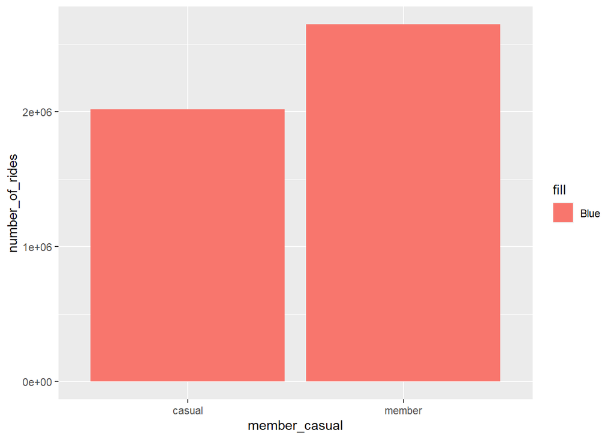

```r
cyclistic_date %>%
  group_by(member_casual) %>%
  summarise(number_of_rides = n(), average_duration = mean(ride_length)) %>%
  arrange(member_casual) %>%
  ggplot(aes(x=member_casual,y=number_of_rides, fill = "Blue")) +
  geom_col(position="dodge")
```

Visualization of number of rides, every day of the week by user type

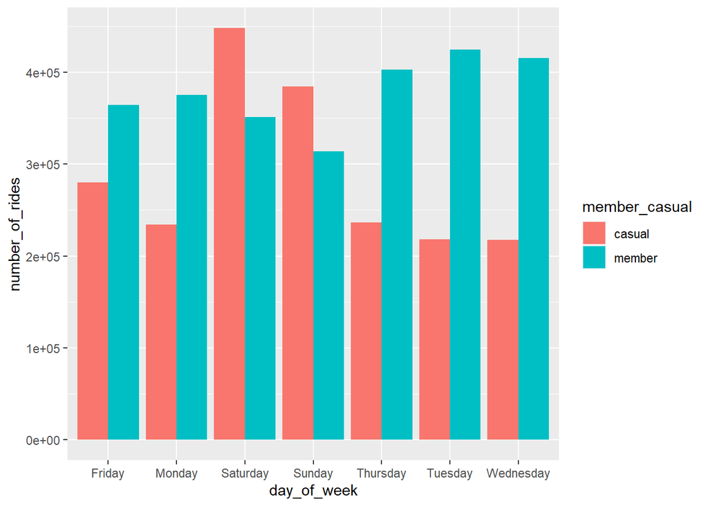

```r
cyclistic_date %>%
  mutate(weekday = wday(started_at)) %>%
  group_by(member_casual,day_of_week) %>%
  summarise(number_of_rides = n(), average_duration = mean(ride_length)) %>%
  arrange(member_casual, day_of_week) %>%
  ggplot(aes(x=day_of_week,y=number_of_rides,fill=member_casual)) +
  geom_col(position="dodge")
```

Visualization of average duration, every day of the week by user type

```
## Defaulting to continuous.
```

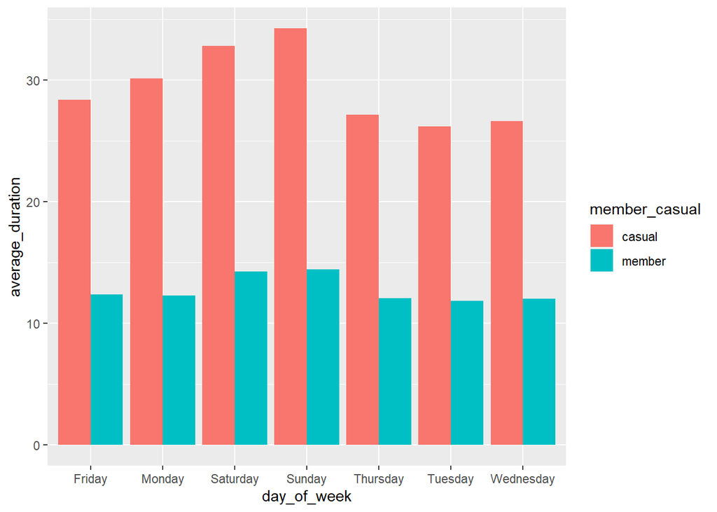

```r
cyclistic_date %>%
  mutate(weekday = wday(started_at)) %>%
  group_by(member_casual,day_of_week) %>%
  summarise(number_of_rides = n(), average_duration = mean(ride_length)) %>%
  arrange(member_casual, day_of_week) %>%
  ggplot(aes(x=day_of_week,y=average_duration,fill=member_casual)) +
  geom_col(position="dodge")
```

Visualization of number of rides of user type, by bike type

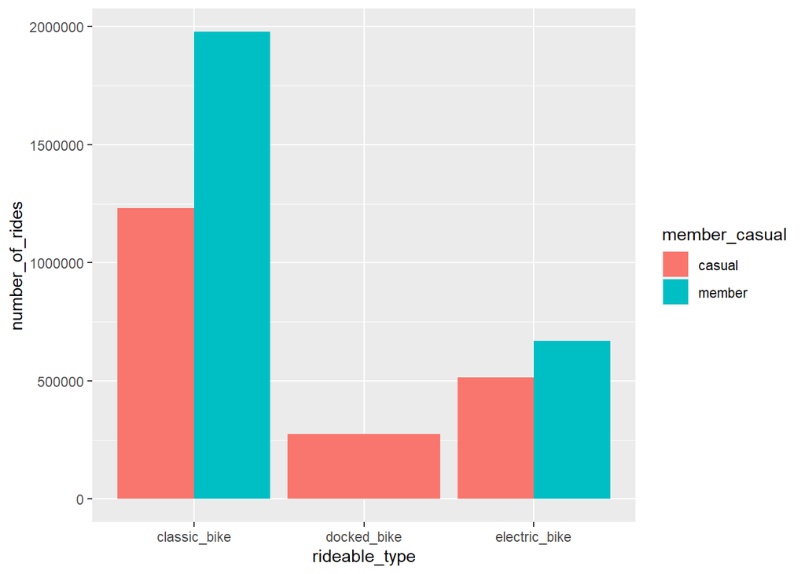

```r
cyclistic_date %>%
  mutate(weekday = wday(started_at)) %>%
  group_by(member_casual,rideable_type) %>%
  summarise(number_of_rides = n(), average_duration = mean(ride_length)) %>%
  arrange(member_casual, rideable_type) %>%
  ggplot(aes(x=rideable_type,y=number_of_rides,fill=member_casual)) +
  geom_col(position="dodge")
```

Visualization of number of rides of user type by time of the day

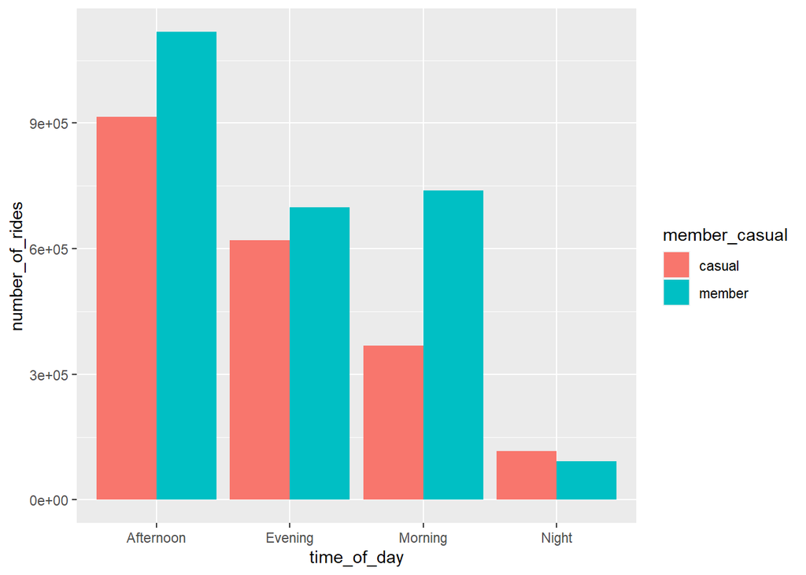

```r
cyclistic_date %>%
  group_by(member_casual,time_of_day) %>%
  summarise(number_of_rides = n(), average_duration = mean(ride_length)) %>%
  arrange(member_casual, time_of_day) %>%
  ggplot(aes(x=time_of_day,y=number_of_rides,fill=member_casual)) +
  geom_col(position="dodge")
```

Visualization of number of rides of user type by seasons

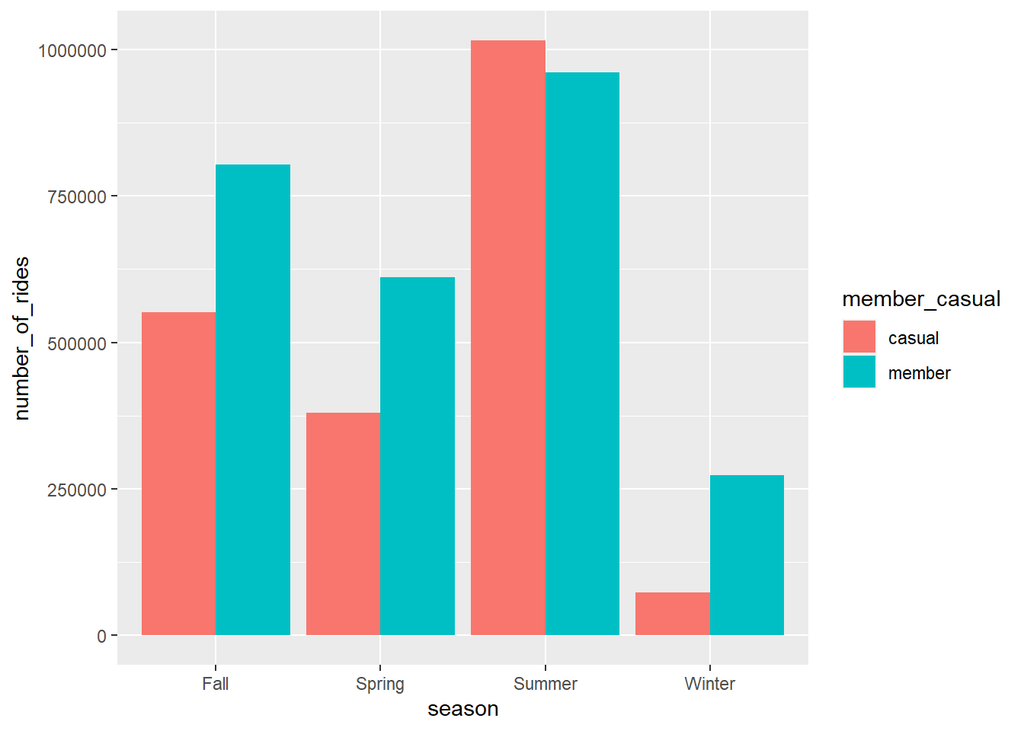

```r
cyclistic_date %>%
  group_by(member_casual,season) %>%
  summarise(number_of_rides = n(), average_duration = mean(ride_length)) %>%
  arrange(member_casual, season) %>%
  ggplot(aes(x=season,y=number_of_rides,fill=member_casual)) +
  geom_col(position="dodge")
```

Visualization of average duration of user type, by bike type

```
## Defaulting to continuous.
```

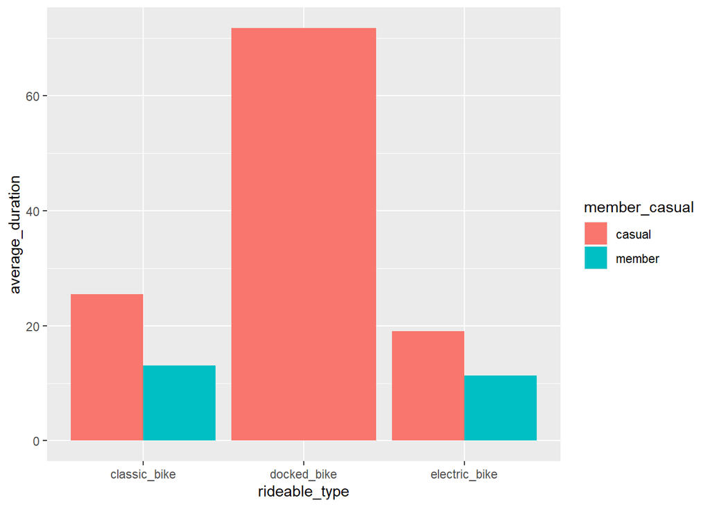

```r
cyclistic_date %>%
  group_by(member_casual,rideable_type) %>%
  summarise(number_of_rides = n(), average_duration = mean(ride_length)) %>%
  arrange(member_casual, rideable_type) %>%
  ggplot(aes(x=rideable_type,y=average_duration,fill=member_casual)) +
  geom_col(position="dodge")
```

Visualization of average duration of user type, by time of the day

```
## Defaulting to continuous.
```

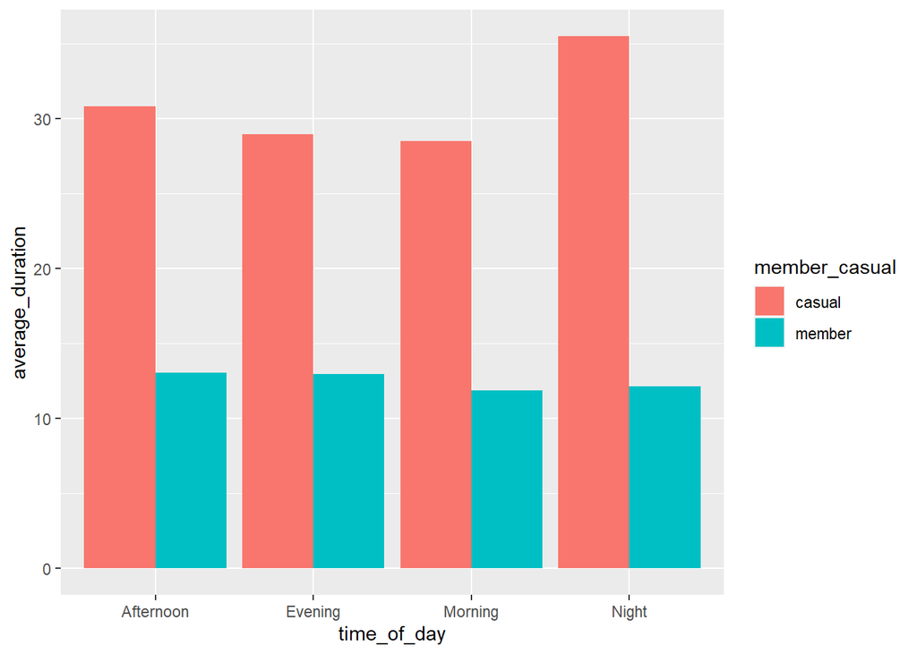

```r
cyclistic_date %>%
  group_by(member_casual,time_of_day) %>%
  summarise(number_of_rides = n(), average_duration = mean(ride_length)) %>%
  arrange(member_casual,time_of_day) %>%
  ggplot(aes(x=time_of_day,y=average_duration,fill=member_casual)) +
  geom_col(position="dodge")
```

Visualization of average duration of user type, by season

```
## Defaulting to continuous.
```

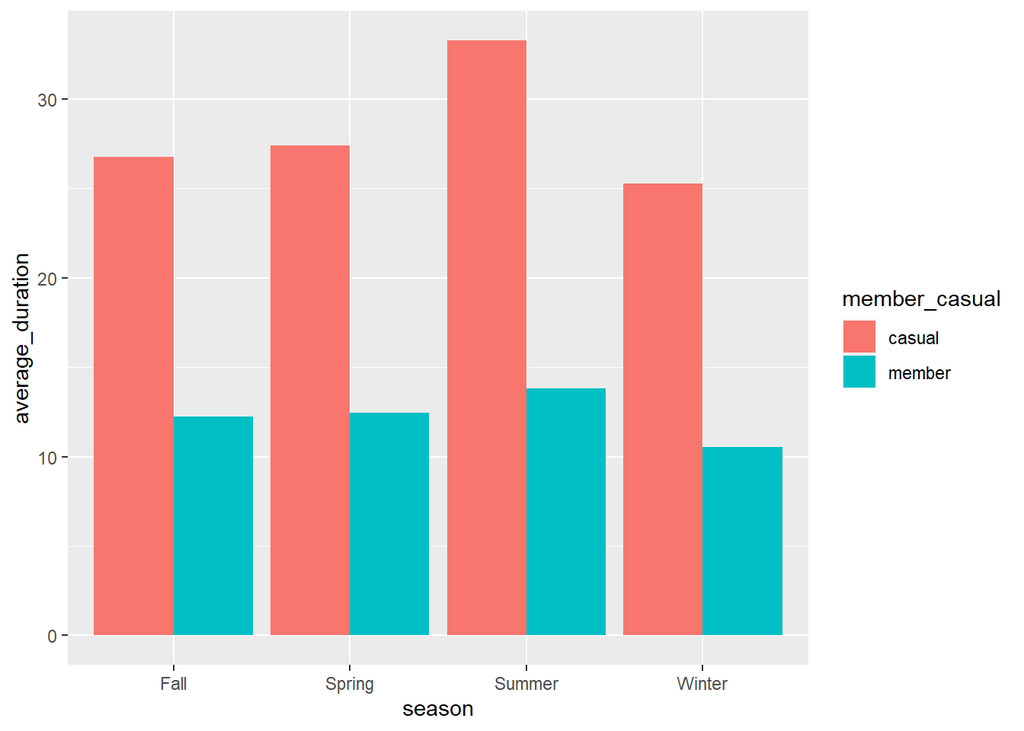

```r
cyclistic_date %>%
  group_by(member_casual,season) %>%
  summarise(number_of_rides = n(), average_duration = mean(ride_length)) %>%
  arrange(member_casual,season) %>%
  ggplot(aes(x=season,y=average_duration,fill=member_casual)) +
  geom_col(position="dodge")
```

#RESULT#

From my analysis, cyclistic, has more annual member riders than casual riders, but casual riders ride longer than annual members. These are the ways in which both user types differ, based on various metrics;

Day of the week : Saturday has the highest number of rides, and most of them are casual riders. Member riders ride more on Wednesday more than casual riders. Casual riders ride longest on Sunday, more than csual riders. Casual riders have longer ride lengths than casual members on all day.

Bike type: Classic bikes are the most popularly used bikes, most of which are member riders, only casual riders use the docked bikes. Docked bikes have the highest ride length by casual riders.

Seasons : Rides are higher and longer in Summer compared to other seasons, but casual riders are more and longer than member riders.